# Customer Segmentation using k-means Clustering

Customer segmentation is the practice of dividing a customer base into groups of individuals that are similar in specific ways relevant to marketing, such as age, gender, interests and spending habits.

For this project, I downloaded the mall customers dataset from Kaggle.

### Importing Libraries

```python
import numpy as np
import pandas as pd
import matplotlib.pyplot as plt
import seaborn as sns
from sklearn.cluster import KMeans
from sklearn.preprocessing import StandardScaler
```

### Loading Data

I am dropping CustomerID column because it is not required for analysis

```python
df = pd.read_csv('D:/USF/Assignments/Customer segmentation using clustering/Mall_Customers.csv')
df = df.drop('CustomerID', axis=1)
df.columns = ['Gender', 'Age', 'Annual_Income', 'Spending_Score']
df.head(5)
```

|  | Gender | Age | Annual_Income | Spending_Score |
| --- | --- | --- | --- | --- |
| 0 | Male | 19 | 15 | 39 |
| 1 | Male | 21 | 15 | 81 |
| 2 | Female | 20 | 16 | 6 |
| 3 | Female | 23 | 16 | 77 |
| 4 | Female | 31 | 17 | 40 |

### Checking the Data

Checking for missing values in the data and shape of the dataset

```python
df.shape
```

```
(200, 4)
```

The dataset has 4 columns with 200 records

```python
df.isnull().sum()
```

```
Gender            0
Age               0
Annual_Income     0
Spending_Score    0
dtype: int64
```

It is evident that there are no missing values in the dataset.

The dataset is clean with no null values and all the fields are stored properly.

### Exploratory data analysis

My goal is to find hidden realtionships and patterns in the dataset.

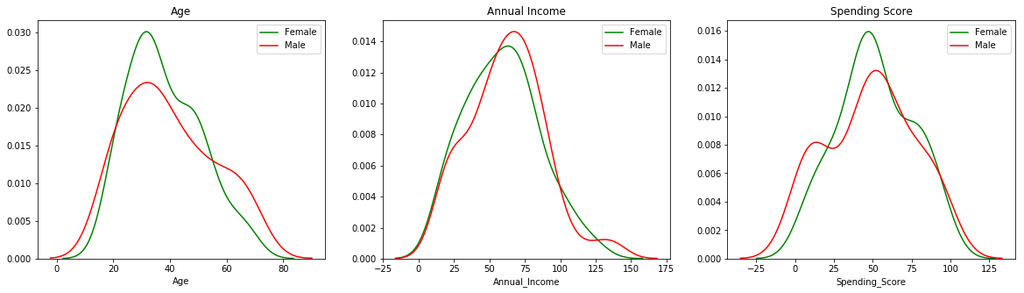

```python
plt.figure(figsize=(20,5))
plt.subplot(1,3,1)
sns.distplot(df.Age[df['Gender']=='Female'], color='green', hist=False, kde=True, label='Female')
sns.distplot(df.Age[df['Gender']=='Male'], color='red', hist=False, kde=True, label='Male')
plt.title('Age')

plt.subplot(1,3,2)
sns.distplot(df.Annual_Income[df['Gender']=='Female'], color='green', hist=False, kde=True, label='Female')
sns.distplot(df.Annual_Income[df['Gender']=='Male'], color='red', hist=False, kde=True, label='Male')
plt.title('Annual Income')

plt.subplot(1,3,3)
sns.distplot(df.Spending_Score[df['Gender']=='Female'], color='green', hist=False, kde=True, label='Female')
sns.distplot(df.Spending_Score[df['Gender']=='Male'], color='red', hist=False, kde=True, label='Male')
plt.title('Spending Score')

plt.show()
```

From thr above plots, we can infer that there are more females between the ages of 20-40 than males. Aslo, there are more females with spending score around 50. We can't infer much from the Annual Income plot.

### Using Box-Plots to compare Age, Annual Income ans Spending Score by Gender

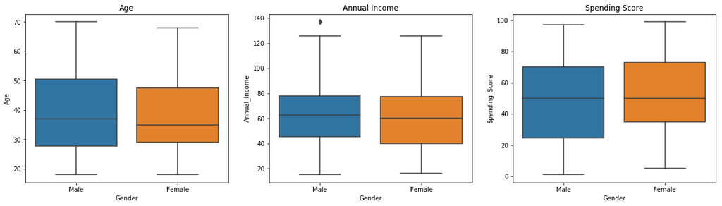

```python
plt.figure(figsize=(20,5))
plt.subplot(1,3,1)
sns.boxplot(x=df.Gender, y=df.Age)
plt.title('Age')

plt.subplot(1,3,2)
sns.boxplot(x=df.Gender, y=df.Annual_Income)
plt.title('Annual Income')

plt.subplot(1,3,3)
sns.boxplot(x=df.Gender, y=df.Spending_Score)
plt.title('Spending Score')

plt.show()
```

In the Annual Income boxplot, there is one outlier on the male side. Aslo, all 3 plots have almost the same median among different groups. The spending score for females seems a bit higher than that of males. This can be inferred from the upper quartile of the female boxplot.

### Using Scatterplot to find relationship between variables

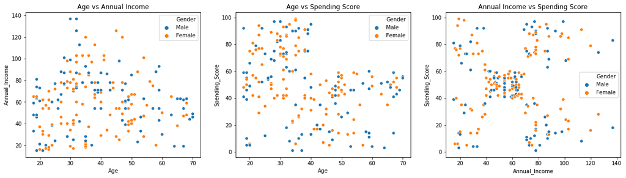

```python
plt.figure(figsize=(20,5))
plt.subplot(1,3,1)
sns.scatterplot(x=df.Age, y=df.Annual_Income, hue=df.Gender)
plt.title('Age vs Annual Income')

plt.subplot(1,3,2)
sns.scatterplot(x=df.Age, y=df.Spending_Score, hue=df.Gender)
plt.title('Age vs Spending Score')

plt.subplot(1,3,3)
sns.scatterplot(x=df.Annual_Income, y=df.Spending_Score, hue=df.Gender)
plt.title('Annual Income vs Spending Score')

plt.show()
```

Although there seems to be no linear relationship between any of the vatiables, from the Age vs Spending Score plot, 2 different groups are visible. Similarly from Annual Income vss Spending Score plot, 5 different groups are visible.

### Annual Income and Spending Score by Age

Finally, I will check if there is a trend when plotting Annual Income or Spending Score by Age

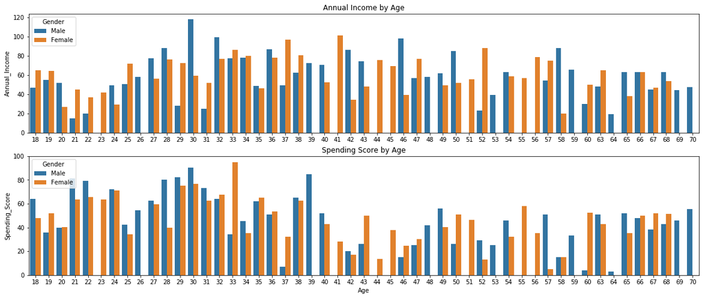

```python
plt.figure(figsize=(20,8))
plt.subplot(2,1,1)
sns.barplot(x=df.Age, y=df.Annual_Income, hue=df.Gender, ci=0)
plt.title('Annual Income by Age')
plt.xlabel('')

plt.subplot(2,1,2)
sns.barplot(x=df.Age, y=df.Spending_Score, hue=df.Gender, ci=0)
plt.title('Spending Score by Age')

plt.show()
```

Spending Score is higher for ages 21-39 compared to other age groups.

### Data Preperation

Since Gender is a categorical variable with 2 values - Male and Female, one-hot encoding is used to convert male=1 and female=0. A new dataframe is created where age, income and score are normalized. This is done just to compare if there will be any difference in elbow method, however all columns except age has pretty much same values so we should not see anything extreme here

```python
df = pd.get_dummies(df, columns=['Gender'], drop_first=True)
df = df.rename(columns={'Gender_Male':'Gender'})
```

```python
# create new dataframe with transformed values
df_t = df.copy()

ss = StandardScaler()
df_t['Age'] = ss.fit_transform(df['Age'].values.reshape(-1,1))
df_t['Annual_Income'] = ss.fit_transform(df['Annual_Income'].values.reshape(-1,1))
df_t['Spending_Score'] = ss.fit_transform(df['Spending_Score'].values.reshape(-1,1))
```

### Transformed vs Original

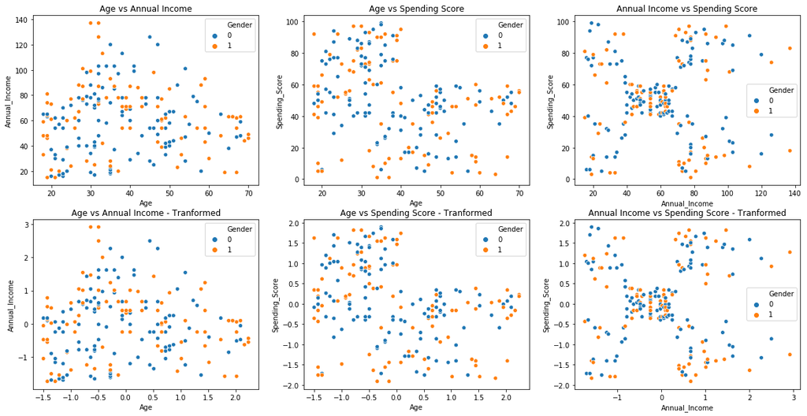

```python
plt.figure(figsize=(20,10))

plt.subplot(2,3,1)
sns.scatterplot(x=df.Age, y=df.Annual_Income, hue=df.Gender)
plt.title('Age vs Annual Income')

plt.subplot(2,3,2)
sns.scatterplot(x=df.Age, y=df.Spending_Score, hue=df.Gender)
plt.title('Age vs Spending Score')

plt.subplot(2,3,3)
sns.scatterplot(x=df.Annual_Income, y=df.Spending_Score, hue=df.Gender)
plt.title('Annual Income vs Spending Score')

plt.subplot(2,3,4)
sns.scatterplot(x=df_t.Age, y=df_t.Annual_Income, hue=df_t.Gender)
plt.title('Age vs Annual Income - Tranformed')

plt.subplot(2,3,5)
sns.scatterplot(x=df_t.Age, y=df_t.Spending_Score, hue=df_t.Gender)
plt.title('Age vs Spending Score - Tranformed')

plt.subplot(2,3,6)
sns.scatterplot(x=df_t.Annual_Income, y=df_t.Spending_Score, hue=df_t.Gender)
plt.title('Annual Income vs Spending Score - Tranformed')

plt.show()
```

There is barely any difference between the transformed and origianl data except for the axis scale.

### Using K-means Clustering

The first step is to find the ideal number of clusters using the elbow method.

Drawing inertia of KMeans on raw data and normalized data

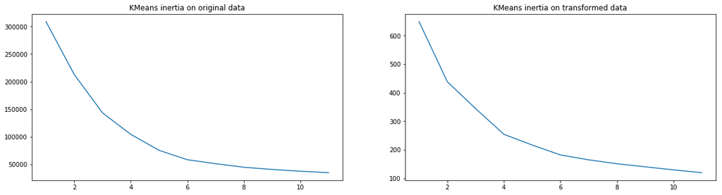

```python
# untransformed data
inertia = []
for i in range(1, 12):
    km = KMeans(n_clusters=i).fit(df)
    inertia.append(km.inertia_)

# transformed data
inertia_t = []
for i in range(1, 12):
    km = KMeans(n_clusters=i).fit(df_t)
    inertia_t.append(km.inertia_)

# plot results
plt.figure(figsize=(20,5))
plt.subplot(1,2,1)
sns.lineplot(x=range(1,12), y=inertia)
plt.title('KMeans inertia on original data')

plt.subplot(1,2,2)
sns.lineplot(x=range(1,12), y=inertia_t)
plt.title('KMeans inertia on transformed data')

plt.show()
```

When looking on inertia for original data: 2, 3 and 5 seems to be our candidates for number of clusters. When looking on inertia in transformed data, 2 and 4 seems to be best. So let us simply check how clustering looks like when using 2, 3, 4 and 5 clusters.

```python
clusters = [2,3,4,5]
cluster_centers = {}

for c in clusters:
    km = KMeans(n_clusters=c).fit(df[['Age', 'Annual_Income', 'Spending_Score', 'Gender']])
    df['cluster' + str(c)] = km.labels_
    cluster_centers[str(c)] = km.cluster_centers_
```

### Choosing the number of clusters for segmentation

Generally k-means clustering has between 2-5 clusters. Using 2 clusters would not help that much as it will only give two segments. When using 5 clusters, we are getting 5 different groups of customers that separates well from each other.

The number of clusters will change based on the business needs.

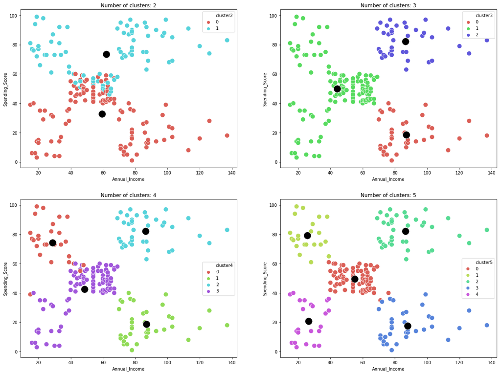

```python
plt.figure(figsize=(20,15))
for i, c in enumerate(clusters):
    plt.subplot(2,2,i+1)
    sns.scatterplot(df.Annual_Income, df.Spending_Score, df['cluster' + str(c)], s=120, palette=sns.color_palette("hls", c))
    sns.scatterplot(cluster_centers[str(c)][:,1], cluster_centers[str(c)][:,2], color='black', s=300)
    plt.title('Number of clusters: ' + str(c))

plt.show()
```

From the above plot it is clearly evident that the plot with 5 clusters produces better results than other plots. Also the segments in the plot with 5 clusters are well seperated. So I will chose 5 as my number of clusters.

### Segmenting using 5 clusters

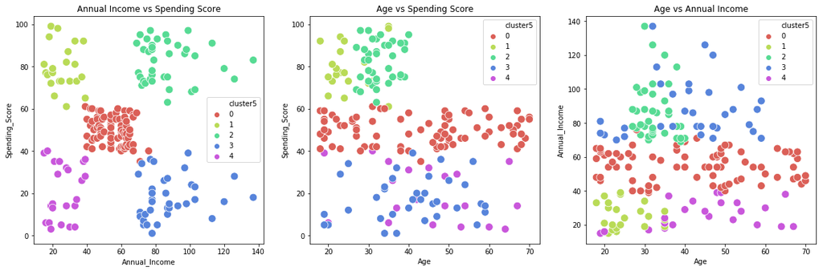

```python
plt.figure(figsize=(20,6))
plt.subplot(1,3,1)
sns.scatterplot(df.Annual_Income, df.Spending_Score, df['cluster5'], s=120, palette=sns.color_palette("hls", 5))
plt.title('Annual Income vs Spending Score')

plt.subplot(1,3,2)
sns.scatterplot(df.Age, df.Spending_Score, df['cluster5'], s=120, palette=sns.color_palette("hls", 5))
plt.title('Age vs Spending Score')

plt.subplot(1,3,3)
sns.scatterplot(df.Age, df.Annual_Income, df['cluster5'], s=120, palette=sns.color_palette("hls", 5))
plt.title('Age vs Annual Income')

plt.show()
```

The Annual income vs Spending score plot performs better than the other two plots. It has 5 different segments

- Low income and Low spending
- Low income and High spending
- Mid income and Mide spending
- High income and Low spending
- High income and Highspending